# si544-day11-inference-for-regression

Drew Pappas

11/15/2019

```r
library(tidyverse)
```

```r
library(infer)
library(moderndive)
library(nycflights13)
library(ggplot2movies)
library(knitr)
```

## t-test

```r
t.test(score ~ gender, evals)
```

```
##
##  Welch Two Sample t-test
##
## data:  score by gender
## t = -2.7507, df = 398.7, p-value = 0.006218
## alternative hypothesis: true difference in means is not equal to 0
## 95 percent confidence interval:
##  -0.24264375 -0.04037194
## sample estimates:
## mean in group female   mean in group male
##             4.092821             4.234328
```

```r
evals_ch6 <- evals %>%
  select(ID, score, bty_avg, age)
glimpse(evals_ch6)
```

```
## Observations: 463
## Variables: 4
## $ ID      <int> 1, 2, 3, 4, 5, 6, 7, 8, 9, 10, 11, 12, 13, 14, 15, 16,...
## $ score   <dbl> 4.7, 4.1, 3.9, 4.8, 4.6, 4.3, 2.8, 4.1, 3.4, 4.5, 3.8,...
## $ bty_avg <dbl> 5.000, 5.000, 5.000, 5.000, 3.000, 3.000, 3.000, 3.333...
## $ age     <int> 36, 36, 36, 36, 59, 59, 59, 51, 51, 40, 40, 40, 40, 40...
```

## Visualization

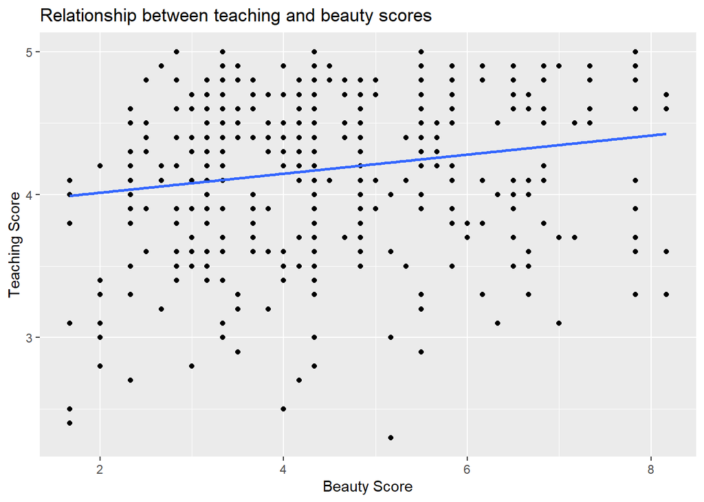

```r
ggplot(evals_ch6, aes(x = bty_avg, y = score)) +
  geom_point() +
  labs(x = "Beauty Score", y = "Teaching Score",
       title = "Relationship between teaching and beauty scores") +
  geom_smooth(method = "lm", se = FALSE)
```

## Teaching Score Model

```r
# Fit regression model:
score_model <- lm(score ~ bty_avg, data = evals_ch6)
# Get regression table:
get_regression_table(score_model)
```

```
## # A tibble: 2 x 7
##   term      estimate std_error statistic p_value lower_ci upper_ci
##   <chr>        <dbl>     <dbl>     <dbl>   <dbl>    <dbl>    <dbl>
## 1 intercept    3.88      0.076     51.0        0    3.73     4.03
## 2 bty_avg      0.067     0.016      4.09       0    0.035    0.099
```

## Normality of Residuals

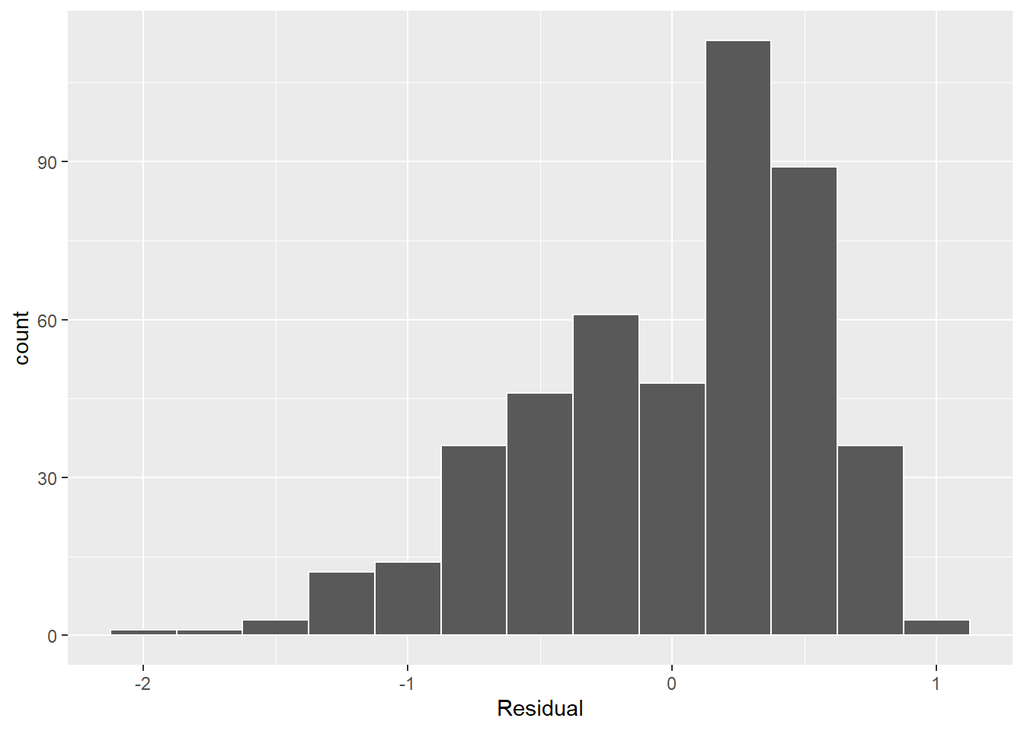

```r
regression_points <- get_regression_points(score_model)
ggplot(regression_points, aes(x = residual)) +
  geom_histogram(binwidth = 0.25, color = "white") +
  labs(x = "Residual")
```

## Residuals vs. Beauty Score

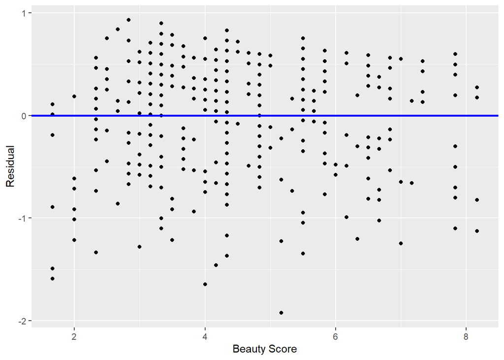

```r
ggplot(regression_points, aes(x = bty_avg, y = residual)) +
  geom_point() +
  labs(x = "Beauty Score", y = "Residual") +
  geom_hline(yintercept = 0, col = "blue", size = 1)
```

## Learning Check 11.1 (10 minutes)

Using age as the explanatory variable and teaching score as the outcome variable, use the get_regression_points() function to get the observed values, fitted values, and residuals for all 463 instructors. Perform a residual analysis and look for any systematic patterns in the residuals. Ideally, there should be little to no pattern.

```r
age_teaching_lm <- lm(score ~ age, data = evals_ch6)

age_teaching_regression_pts <- get_regression_points(age_teaching_lm)

age_teaching_regression_pts
```

```
## # A tibble: 463 x 5
##       ID score   age score_hat residual
##    <int> <dbl> <int>     <dbl>    <dbl>
##  1     1   4.7    36      4.25    0.452
##  2     2   4.1    36      4.25   -0.148
##  3     3   3.9    36      4.25   -0.348
##  4     4   4.8    36      4.25    0.552
##  5     5   4.6    59      4.11    0.488
##  6     6   4.3    59      4.11    0.188
##  7     7   2.8    59      4.11   -1.31
##  8     8   4.1    51      4.16   -0.059
##  9     9   3.4    51      4.16   -0.759
## 10    10   4.5    40      4.22    0.276
## # ... with 453 more rows
```

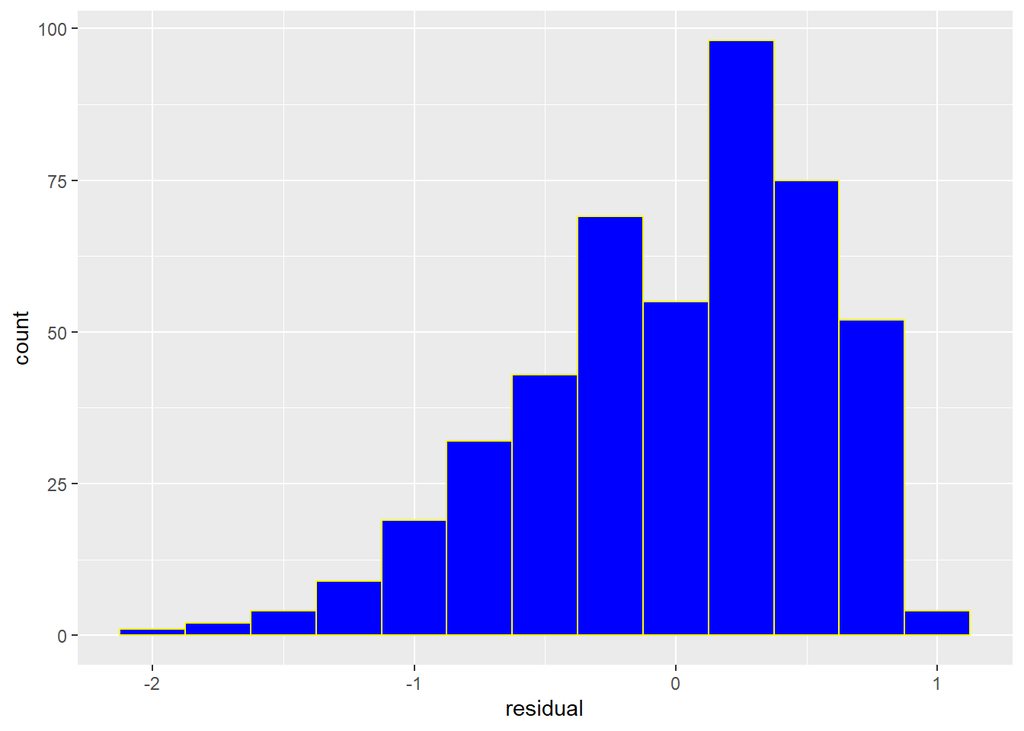

```r
ggplot(age_teaching_regression_pts, aes(x = residual))+
  geom_histogram(fill = 'blue', color = 'yellow', binwidth = .25)
```

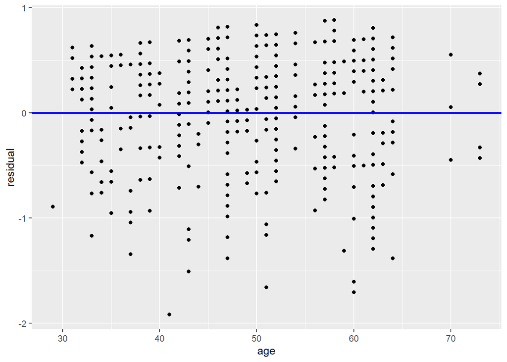

```r
ggplot(age_teaching_regression_pts, aes(x = age, y = residual))+
  geom_point()+
  geom_hline(yintercept = 0, col = 'blue', size = 1)
```

From the two visualizations created above, there does not seem to be any systemic patterns to the residuals. The distribution of residuals is approximately normal, but one could argue that there is a slight left skew. The variance of residuals is approximately equal as well.

## Bootstrapping the slope

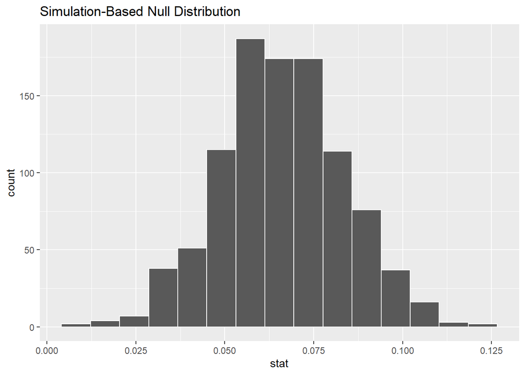

```r
bootstrap_distn_slope <- evals_ch6 %>%
  specify(formula = score ~ bty_avg) %>%
  generate(reps = 1000, type = "bootstrap") %>%
  calculate(stat = "slope")
visualize(bootstrap_distn_slope)
```

## 95% CI for bootstrapped slope

```r
percentile_ci <- bootstrap_distn_slope %>%
  get_confidence_interval(type = "percentile", level = 0.95)
percentile_ci
```

```
## # A tibble: 1 x 2
##   `2.5%` `97.5%`
##    <dbl>   <dbl>
## 1 0.0321   0.101
```

```r
observed_slope <- evals %>%
  specify(score ~ bty_avg) %>%
  calculate(stat = "slope")
observed_slope
```

```
## # A tibble: 1 x 1
##     stat
##    <dbl>
## 1 0.0666
```

```r
se_ci <- bootstrap_distn_slope %>%
  get_ci(level = 0.95, type = "se", point_estimate = observed_slope)
se_ci
```

```
## # A tibble: 1 x 2
##    lower upper
##    <dbl> <dbl>
## 1 0.0325 0.101
```

## Comparing CIs

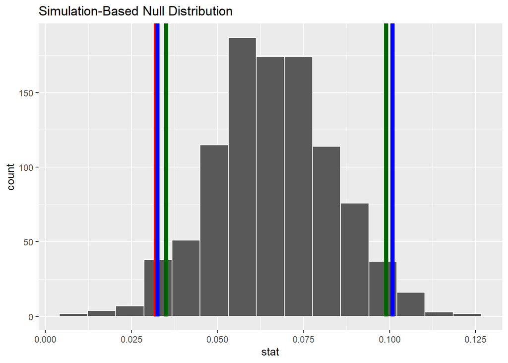

```r
visualize(bootstrap_distn_slope) +
  shade_confidence_interval(endpoints = percentile_ci, fill = NULL,
                            color = "red") +
  shade_confidence_interval(endpoints = se_ci, fill = NULL,
                            color = "blue") +
  shade_confidence_interval(endpoints = c(0.035, 0.099), fill = NULL,
                            color = "darkgreen")
```

## Hypothesis tests around the slope

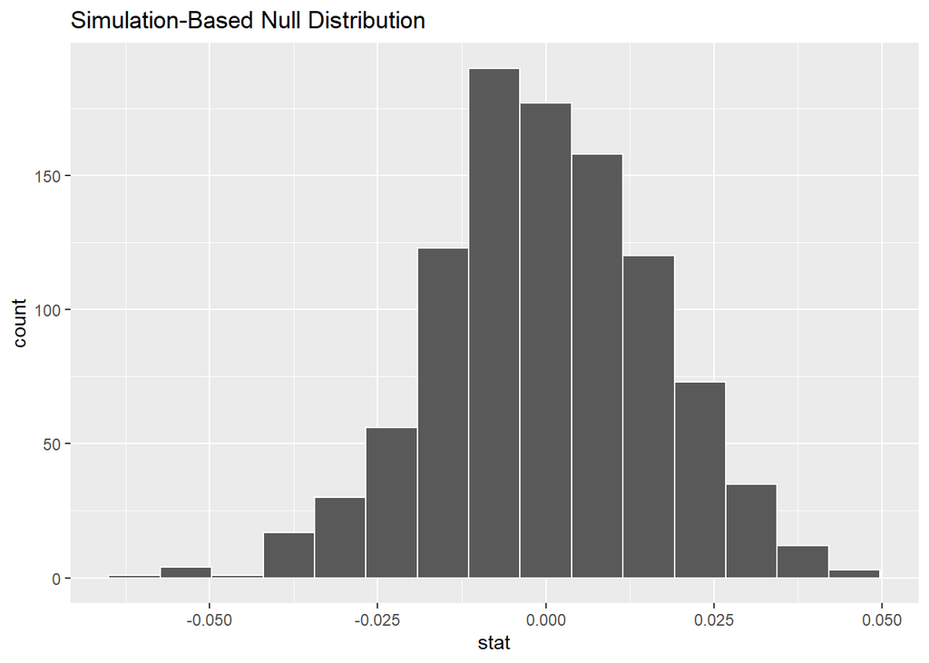

```r
null_distn_slope <- evals %>%
  specify(score ~ bty_avg) %>%
  hypothesize(null = "independence") %>%
  generate(reps = 1000, type = "permute") %>%
  calculate(stat = "slope")
visualize(null_distn_slope)
```

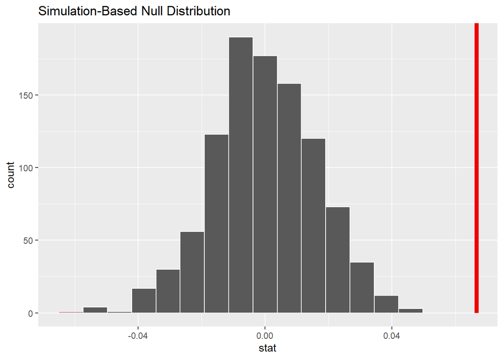

```r
visualize(null_distn_slope) +
  shade_p_value(obs_stat = observed_slope, direction = "both")
```

```r
null_distn_slope %>%
  get_p_value(obs_stat = observed_slope, direction = "both")
```

```
## # A tibble: 1 x 1
##   p_value
##     <dbl>
## 1       0
```

## Learning Check 11.2 (10 minutes)

Repeat the inference above but this time for the correlation coefficient instead of the slope. Note the implementation of stat = “correlation” in the calculate() function of the infer package.

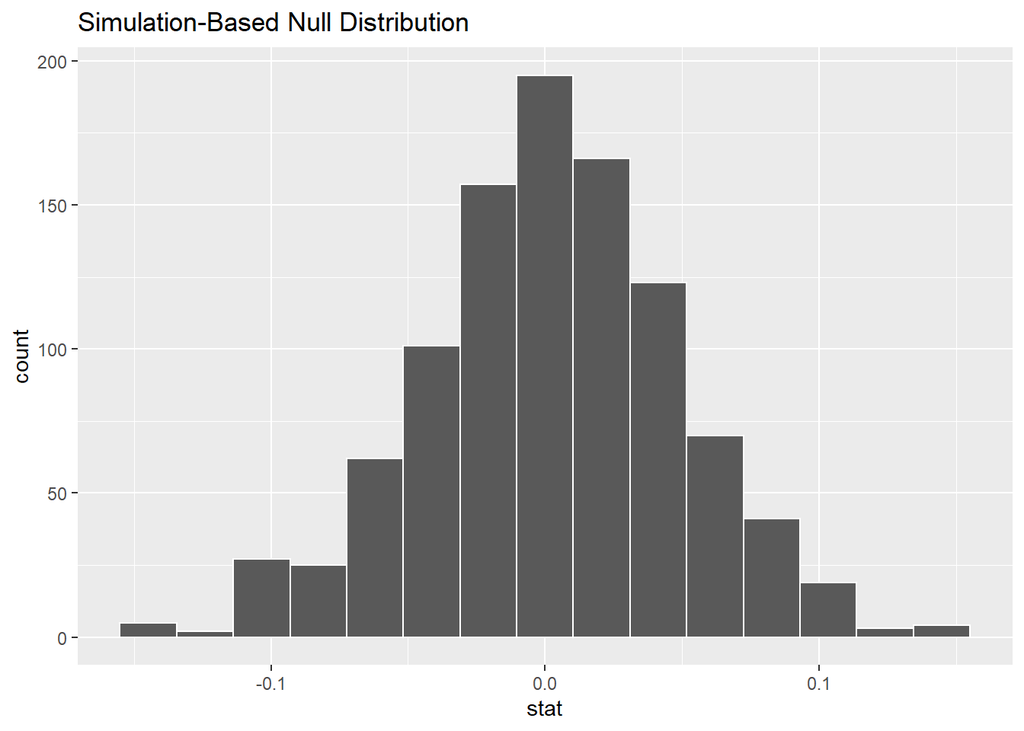

```r
correlation_null <- evals %>%
  specify(score ~ bty_avg) %>%
  hypothesize(null = "independence") %>%
  generate(reps = 1000, type = "permute") %>%
  calculate(stat = "correlation")

visualize(correlation_null)
```

```r
observed_corr <- evals %>%
  specify(score ~ bty_avg) %>%
  calculate(stat = "correlation")

observed_corr
```

```
## # A tibble: 1 x 1
##    stat
##   <dbl>
## 1 0.187
```

```r
correlation_null %>%
  get_p_value(obs_stat = observed_corr, direction = "both")
```

```
## # A tibble: 1 x 1
##   p_value
##     <dbl>
## 1       0
```

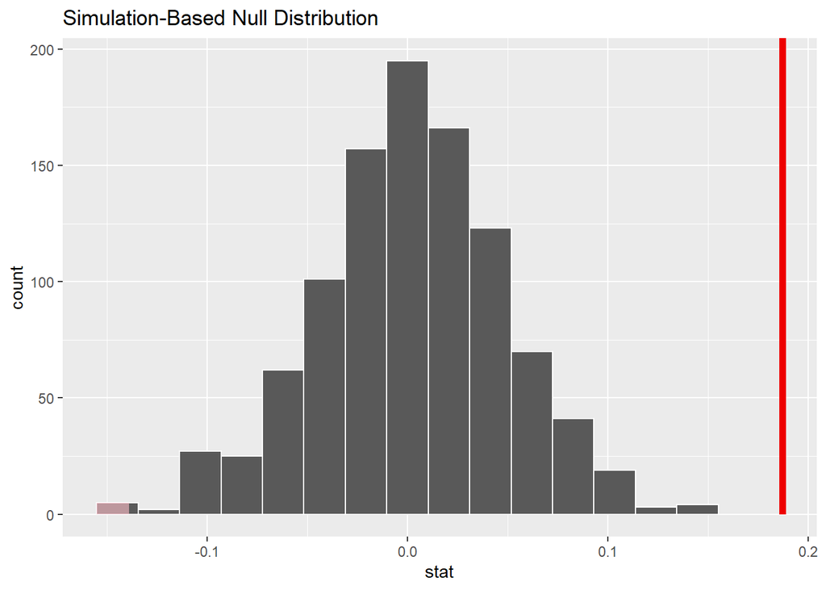

```r
visualize(correlation_null) +
  shade_p_value(obs_stat = observed_corr, direction = "both")
```

Given an alpha of 0.05 and a p value as extreme as the one we see, we have sufficient evidence to reject the null hypothesis that the correlation coefficient between score and beauty average is 0.